# R Notebook

```r
install.packages(c("gmodels", "ggplot2", "vcd","agricolae","tidyverse", "Hmisc", "psych", "fBasics", "treemap", "ggmap", "mosaic"),dependencies = c("Depends"))
```

```r
#########################################################
# Ejemplo: Marketing Directo                          #
#########################################################

# Lectura de datos
DMark <- read.csv("MarketingDirecto.csv")
head(DMark)
```

|  | Edad | Genero | Vivienda | Ecivil | Ubicacion | Salario | Hijos | Historial | Catalogos | Monto |
| --- | --- | --- | --- | --- | --- | --- | --- | --- | --- | --- |
| 1 | Adulta | Femenino | Propia | Soltero | Lejos | 47500 | 0 | Alto | 6 | 755 |
| 2 | Media | Masculino | Alquilada | Soltero | Cerca | 63600 | 0 | Alto | 6 | 1318 |
| 3 | Joven | Femenino | Alquilada | Soltero | Cerca | 13500 | 0 | Bajo | 18 | 296 |
| 4 | Media | Masculino | Propia | Casado | Cerca | 85600 | 1 | Alto | 18 | 2436 |
| 5 | Media | Femenino | Propia | Soltero | Cerca | 68400 | 0 | Alto | 12 | 1304 |
| 6 | Joven | Masculino | Propia | Casado | Cerca | 30400 | 0 | Bajo | 6 | 495 |

```r
str(DMark)
```

```
'data.frame':   1000 obs. of  10 variables:
 $ Edad     : Factor w/ 3 levels "Adulta","Joven",..: 1 3 2 3 3 2 3 3 3 1 ...
 $ Genero   : Factor w/ 2 levels "Femenino","Masculino": 1 2 1 2 1 2 1 2 1 2 ...
 $ Vivienda : Factor w/ 2 levels "Alquilada","Propia": 2 1 1 2 2 2 1 2 2 2 ...
 $ Ecivil   : Factor w/ 2 levels "Casado","Soltero": 2 2 2 1 2 1 2 2 1 1 ...
 $ Ubicacion: Factor w/ 2 levels "Cerca","Lejos": 2 1 1 1 1 1 1 1 1 2 ...
 $ Salario  : int  47500 63600 13500 85600 68400 30400 48100 68400 51900 80700 ...
 $ Hijos    : int  0 0 0 1 0 0 0 0 3 0 ...
 $ Historial: Factor w/ 3 levels "Alto","Bajo",..: 1 1 2 1 1 2 3 1 2 NA ...
 $ Catalogos: int  6 6 18 18 12 6 12 18 6 18 ...
 $ Monto    : int  755 1318 296 2436 1304 495 782 1155 158 3034 ...
```

# I.- ORGANIZAR Y VISUALIZAR

Hay 10 variables porque hay 10 atributos que se estan estudiando Varias de los atributos son de tipo ordinal, en este caso en R les asigna como Factor. No necesariamente es el orden que esperamos, de modo que en la forma descriptiva no se aprecia, se muestra una forma, no es necesariamente la mas optima

```r
# Lo ordeno bajo un criterio y sobreescribo la variable
DMark$Edad = factor(DMark$Edad,levels = c("Joven","Media","Adulta"),ordered=TRUE)
DMark$Historial = factor(DMark$Historial,levels = c("Bajo","Medio","Alto"),ordered=TRUE)
#DMark$Edad <- ordered(DMark$Edad, levels =  c("Joven","Media","Adulta"))
```

```r
str(DMark)
```

```
'data.frame':   1000 obs. of  10 variables:
 $ Edad     : Ord.factor w/ 3 levels "Joven"<"Media"<..: 3 2 1 2 2 1 2 2 2 3 ...
 $ Genero   : Factor w/ 2 levels "Femenino","Masculino": 1 2 1 2 1 2 1 2 1 2 ...
 $ Vivienda : Factor w/ 2 levels "Alquilada","Propia": 2 1 1 2 2 2 1 2 2 2 ...
 $ Ecivil   : Factor w/ 2 levels "Casado","Soltero": 2 2 2 1 2 1 2 2 1 1 ...
 $ Ubicacion: Factor w/ 2 levels "Cerca","Lejos": 2 1 1 1 1 1 1 1 1 2 ...
 $ Salario  : int  47500 63600 13500 85600 68400 30400 48100 68400 51900 80700 ...
 $ Hijos    : int  0 0 0 1 0 0 0 0 3 0 ...
 $ Historial: Ord.factor w/ 3 levels "Bajo"<"Medio"<..: 3 3 1 3 3 1 2 3 1 NA ...
 $ Catalogos: int  6 6 18 18 12 6 12 18 6 18 ...
 $ Monto    : int  755 1318 296 2436 1304 495 782 1155 158 3034 ...
```

En el resultado se muestra “Ord.factor” que significa que los datos estan ordenados

#Se procede a revisar las diferentes tecnicas de epxloracion

# Tecnica de Organizacion y Visualizacion de datos

Se empieza con las variables cualitativas

#Presente una tabla de distribucion de frecuencia para la edad del cliente. Construya una grafica adecuada

#——————————————————————# # a) Representacion de Datos Cualitativos # #——————————————————————#

```r
# -------------------
# Tabla de Frecuencia
# -------------------
ni<-table(DMark$Edad) # Son los conteos
fi<-prop.table(ni) # Calculo de frecuencias absolutas
pi<-prop.table(ni)*100 # Calculo de frecuencias relativas
edad.tabla<-t(rbind(ni,fi,pi))
edad.tabla
```

```
        ni    fi   pi
Joven  287 0.287 28.7
Media  508 0.508 50.8
Adulta 205 0.205 20.5
```

Lo mas frecuente son los clientes que tiene una edad “Media” , y son pocos los cliente “Adutlos”

```r
table(DMark$Edad)
```

```
 Joven  Media Adulta
   287    508    205
```

```r
prop.table(table(DMark$Edad)) %>% round(digits = 2)
```

[output not shown]

```r
## Similar a SAS o SPSS
library(gmodels)
CrossTable(DMark$Edad, format="SAS") # Muestra la frecuencia relativa
```

```
   Cell Contents
|-------------------------|
|                       N |
|         N / Table Total |
|-------------------------|


Total Observations in Table:  1000


          |     Joven |     Media |    Adulta |
          |-----------|-----------|-----------|
          |       287 |       508 |       205 |
          |     0.287 |     0.508 |     0.205 |
          |-----------|-----------|-----------|
```

```r
CrossTable(DMark$Edad, format="SPSS") # Muestra la frecuencia porcentual
```

```
   Cell Contents
|-------------------------|
|                   Count |
|             Row Percent |
|-------------------------|

Total Observations in Table:  1000

          |    Joven  |    Media  |   Adulta  |
          |-----------|-----------|-----------|
          |      287  |      508  |      205  |
          |   28.700% |   50.800% |   20.500% |
          |-----------|-----------|-----------|
```

Grafica de Pie : No es recomendable si tiene muchas categorias, si son 2 atributos esta bien Grafica de Barras : Si son varias categorias es recomendable

Si es ordinal si es preferibles usar Barras

# ————————————————

# Visualizacion de la Distribucion de la Variable

# ————————————————

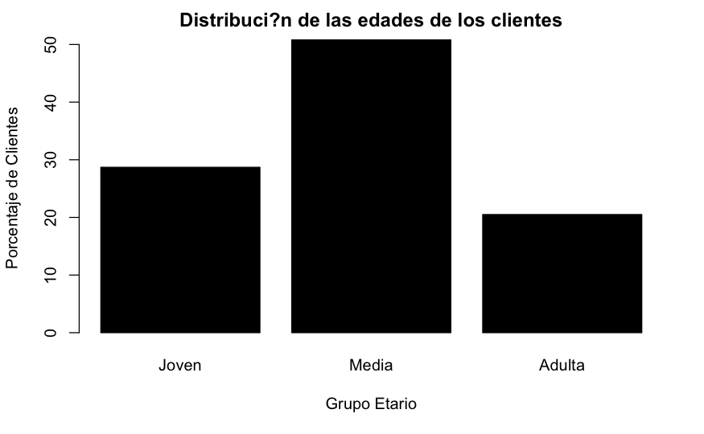

```r
# Grafico de Barras
# -------------------
barplot(pi, main="Distribuci?n de las edades de los clientes",
        xlab="Grupo Etario", col = 1,
        ylab="Porcentaje de Clientes")
```

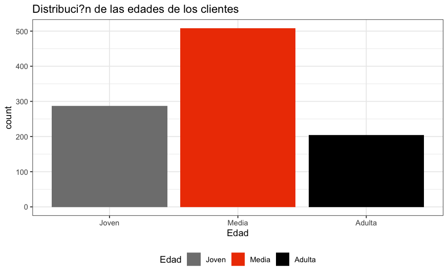

```r
# Usando ggplot2
library(ggplot2)
ggplot(data = DMark, aes(x = Edad, y = ..count.., fill = Edad)) +
  geom_bar() +
  scale_fill_manual(values = c("gray50", "orangered2","black")) +
  labs(title = "Distribuci?n de las edades de los clientes") +
  theme_bw() +
  theme(legend.position = "bottom")
```

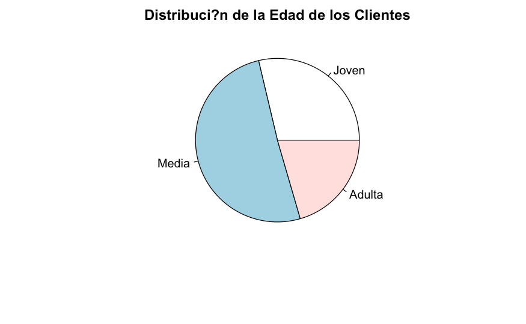

```r
# Gr?fico de Sectores Circulares
# ------------------------------
pie(pi, main="Distribuci?n de la Edad de los Clientes")
```

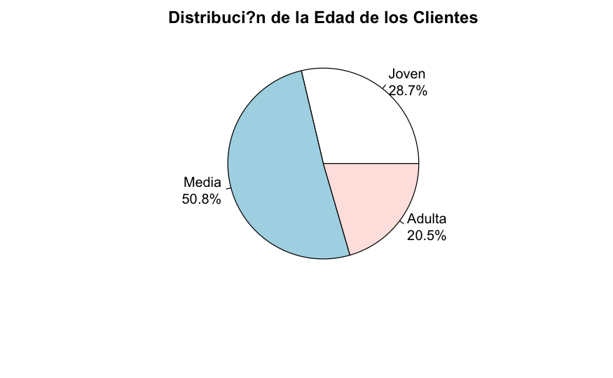

```r
## Colocar porcentajes
lbls1 <- paste(names(table(DMark$Edad)), "\n",
               prop.table(table(DMark$Edad))*100,"%", sep="")
pie(pi, labels = lbls1,
    main="Distribuci?n de la Edad de los Clientes")
```

```r
# Usando ggplot2
df = as.data.frame(fi) ; df #Convertir la tabla a un data frame
```

| Var1 | Freq |
| --- | --- |
| Joven | 0.287 |
| Media | 0.508 |
| Adulta | 0.205 |

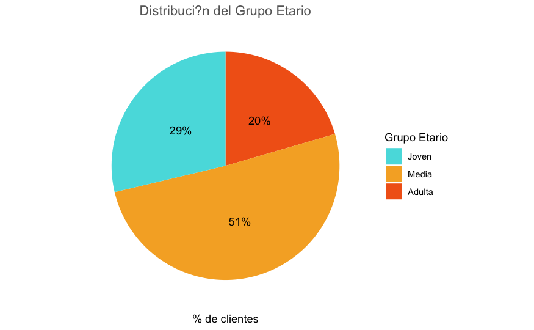

```r
pie = ggplot(df, aes(x="", y=Freq, fill=Var1)) + geom_bar(stat="identity", width=1) # Crea una barra simple
pie = pie + coord_polar("y", start=0) +
      geom_text(aes(label = paste0(round(Freq*100), "%")),
                    position = position_stack(vjust = 0.5)) #Convertir a pie (coordenadas polares)
pie = pie + scale_fill_manual(values=c("#55DDE0", "#F6AE2D", "#F26419", "#999999")) #Escala de colores
pie = pie + labs(x = NULL, y = "% de clientes",
                           fill = "Grupo Etario",
                          title = "Distribuci?n del Grupo Etario") # Remover y a?adir etiquetas/t?tulo
pie = pie + theme_classic() + theme(axis.line = element_blank(),
                                    axis.text = element_blank(),
                                    axis.ticks = element_blank(),
                                    plot.title = element_text(hjust = 0.5, color = "#666666")) # Limpiar el formato
pie
```

```
'x' is neither a vector nor a matrix: using as.numeric(x)
```

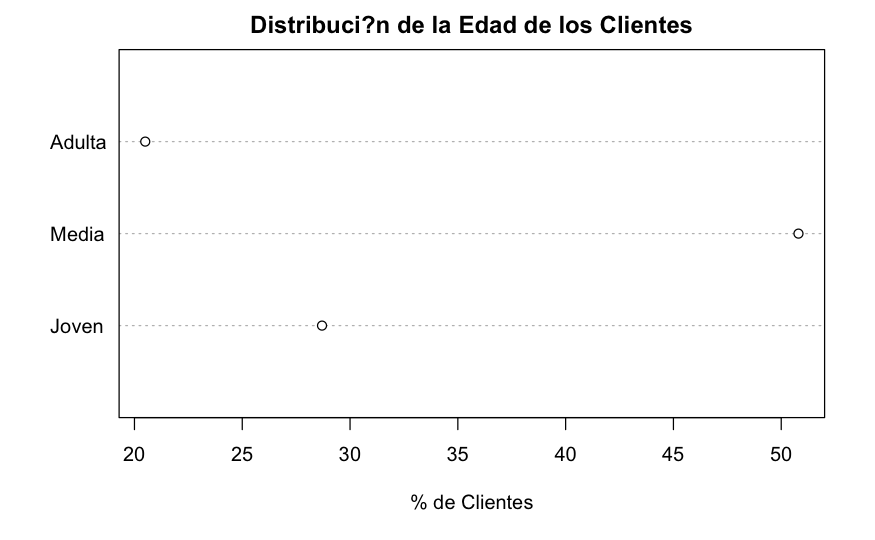

```r
# Dot Plots
# ---------
dotchart(prop.table(table(DMark$Edad))*100,
         main="Distribuci?n de la Edad de los Clientes",
         xlab="% de Clientes")
```

Todo esto se ha hecho con variables cualitativas

Se tiene que buscar si existe alguna relacion entre las variables cualitativas, eso se hace a traves de una tabla de contigencias.